# Germany

1. Cài đặt thư viện mlxtend và xlrd

Sau khi cài đặt, import các thư viện cần thiết: thư viện máy học (mlxtend)

```python
import pandas as pd
import seaborn as sns
import matplotlib.pyplot as plt
%matplotlib inline
from mlxtend.frequent_patterns import apriori
from mlxtend.frequent_patterns import association_rules
```

```python
with open('F:\DOWNLOAD\KHAI THAC DL\DATA\OR.csv') as f:
    df = pd.read_csv(f)
```

Sau khi dữ liệu được đọc vào biến df, hiển thị một vài thông tin của biến này

```python
df.info()
```

```
<class 'pandas.core.frame.DataFrame'>
RangeIndex: 541909 entries, 0 to 541908
Data columns (total 8 columns):
 #   Column       Non-Null Count   Dtype
---  ------       --------------   -----
 0   InvoiceNo    541909 non-null  object
 1   StockCode    541909 non-null  object
 2   Description  540455 non-null  object
 3   Quantity     541909 non-null  int64
 4   InvoiceDate  541909 non-null  object
 5   UnitPrice    541909 non-null  float64
 6   CustomerID   406829 non-null  float64
 7   Country      541909 non-null  object
dtypes: float64(2), int64(1), object(5)
memory usage: 33.1+ MB
```

1. Loại bỏ ký tự thừa ở tên mặt hàng mua (Description), xóa các dòng dữ liệu không có số hóa đơn (cột Invoice No) và chuyển nó về kiểu dữ liệu chuỗi.

```python
df['Description'] = df['Description'].str.strip()
df.dropna(axis=0, subset=['InvoiceNo'], inplace=True)
df['InvoiceNo'] = df['InvoiceNo'].astype('str')
```

Xem thử 10 dòng đầu của dữ liệu sau khi đã thực hiện thao tác làm sạch

```python
df.head(10)
```

|  | InvoiceNo | StockCode | Description | Quantity | InvoiceDate | UnitPrice | CustomerID | Country |
| --- | --- | --- | --- | --- | --- | --- | --- | --- |
| 0 | 536365 | 85123A | WHITE HANGING HEART T-LIGHT HOLDER | 6 | 12/1/2010 8:26 | 2.55 | 17850.0 | United Kingdom |
| 1 | 536365 | 71053 | WHITE METAL LANTERN | 6 | 12/1/2010 8:26 | 3.39 | 17850.0 | United Kingdom |
| 2 | 536365 | 84406B | CREAM CUPID HEARTS COAT HANGER | 8 | 12/1/2010 8:26 | 2.75 | 17850.0 | United Kingdom |
| 3 | 536365 | 84029G | KNITTED UNION FLAG HOT WATER BOTTLE | 6 | 12/1/2010 8:26 | 3.39 | 17850.0 | United Kingdom |
| 4 | 536365 | 84029E | RED WOOLLY HOTTIE WHITE HEART. | 6 | 12/1/2010 8:26 | 3.39 | 17850.0 | United Kingdom |
| 5 | 536365 | 22752 | SET 7 BABUSHKA NESTING BOXES | 2 | 12/1/2010 8:26 | 7.65 | 17850.0 | United Kingdom |
| 6 | 536365 | 21730 | GLASS STAR FROSTED T-LIGHT HOLDER | 6 | 12/1/2010 8:26 | 4.25 | 17850.0 | United Kingdom |
| 7 | 536366 | 22633 | HAND WARMER UNION JACK | 6 | 12/1/2010 8:28 | 1.85 | 17850.0 | United Kingdom |
| 8 | 536366 | 22632 | HAND WARMER RED POLKA DOT | 6 | 12/1/2010 8:28 | 1.85 | 17850.0 | United Kingdom |
| 9 | 536367 | 84879 | ASSORTED COLOUR BIRD ORNAMENT | 32 | 12/1/2010 8:34 | 1.69 | 13047.0 | United Kingdom |

Có thể xem một ví dụ về loại hóa đơn tín dụng bằng câu lệnh sau

```python
df[df.InvoiceNo.str.contains('C', na=False)].head()
```

|  | InvoiceNo | StockCode | Description | Quantity | InvoiceDate | UnitPrice | CustomerID | Country |
| --- | --- | --- | --- | --- | --- | --- | --- | --- |
| 141 | C536379 | D | Discount | -1 | 12/1/2010 9:41 | 27.50 | 14527.0 | United Kingdom |
| 154 | C536383 | 35004C | SET OF 3 COLOURED FLYING DUCKS | -1 | 12/1/2010 9:49 | 4.65 | 15311.0 | United Kingdom |
| 235 | C536391 | 22556 | PLASTERS IN TIN CIRCUS PARADE | -12 | 12/1/2010 10:24 | 1.65 | 17548.0 | United Kingdom |
| 236 | C536391 | 21984 | PACK OF 12 PINK PAISLEY TISSUES | -24 | 12/1/2010 10:24 | 0.29 | 17548.0 | United Kingdom |
| 237 | C536391 | 21983 | PACK OF 12 BLUE PAISLEY TISSUES | -24 | 12/1/2010 10:24 | 0.29 | 17548.0 | United Kingdom |

Tiến hành xóa những hóa đơn tín dụng

```python
df=df[~df['InvoiceNo'].str.contains('C')]
```

1. Thống kê dòng dữ liệu theo từng quốc gia

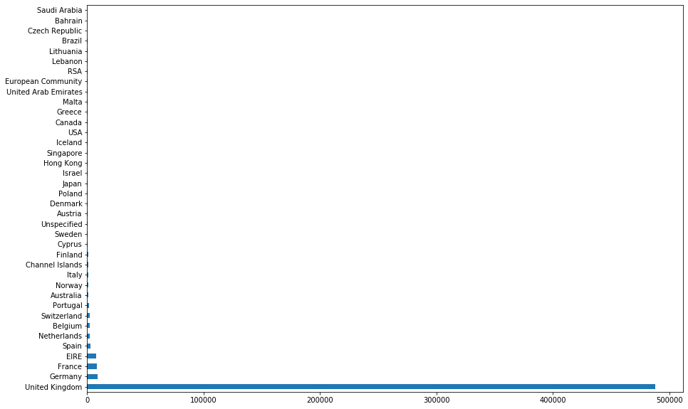

```python
df['Country'].value_counts().plot(kind='barh', figsize=(15,10))
```

Kết quả được hiển thị như hình trên.

1. Chỉ xét các hóa đơn từ nước Đức và nhóm dữ liệu theo Số hóa đơn, Tên mặt hàng.

```python
basket = df[df['Country'] == "Germany"].groupby(['InvoiceNo', 'Description'])['Quantity']
```

1. Chuyển đổi dữ liệu về dạng hot encoding, với mỗi dòng dữ liệu là một hóa đơn

```python
basket = basket.sum().unstack().reset_index().fillna(0).set_index('InvoiceNo')
```

Xem dữ liệu sau khi chuyển về dạng hot encoding

```python
basket.head(10)
```

| Description InvoiceNo | 10 COLOUR SPACEBOY PEN | 12 COLOURED PARTY BALLOONS | 12 IVORY ROSE PEG PLACE SETTINGS | 12 MESSAGE CARDS WITH ENVELOPES | 12 PENCIL SMALL TUBE WOODLAND | 12 PENCILS SMALL TUBE RED RETROSPOT | 12 PENCILS SMALL TUBE SKULL | 12 PENCILS TALL TUBE POSY | 12 PENCILS TALL TUBE RED RETROSPOT | 12 PENCILS TALL TUBE SKULLS | ... | YULETIDE IMAGES GIFT WRAP SET | ZINC HEART T-LIGHT HOLDER | ZINC STAR T-LIGHT HOLDER | ZINC BOX SIGN HOME | ZINC FOLKART SLEIGH BELLS | ZINC HEART LATTICE T-LIGHT HOLDER | ZINC METAL HEART DECORATION | ZINC T-LIGHT HOLDER STAR LARGE | ZINC T-LIGHT HOLDER STARS SMALL | ZINC WILLIE WINKIE CANDLE STICK |
| --- | --- | --- | --- | --- | --- | --- | --- | --- | --- | --- | --- | --- | --- | --- | --- | --- | --- | --- | --- | --- | --- |
| 536527 | 0.0 | 0.0 | 0.0 | 0.0 | 0.0 | 0.0 | 0.0 | 0.0 | 0.0 | 0.0 | ... | 0.0 | 0.0 | 0.0 | 0.0 | 0.0 | 0.0 | 0.0 | 0.0 | 0.0 | 0.0 |
| 536840 | 0.0 | 0.0 | 0.0 | 0.0 | 0.0 | 0.0 | 0.0 | 0.0 | 0.0 | 0.0 | ... | 0.0 | 0.0 | 0.0 | 0.0 | 0.0 | 0.0 | 0.0 | 0.0 | 0.0 | 0.0 |
| 536861 | 0.0 | 0.0 | 0.0 | 0.0 | 0.0 | 0.0 | 0.0 | 0.0 | 0.0 | 0.0 | ... | 0.0 | 0.0 | 0.0 | 0.0 | 0.0 | 0.0 | 0.0 | 0.0 | 0.0 | 0.0 |
| 536967 | 0.0 | 0.0 | 0.0 | 0.0 | 0.0 | 0.0 | 0.0 | 0.0 | 0.0 | 0.0 | ... | 0.0 | 0.0 | 0.0 | 0.0 | 0.0 | 0.0 | 0.0 | 0.0 | 0.0 | 0.0 |
| 536983 | 0.0 | 0.0 | 0.0 | 0.0 | 0.0 | 0.0 | 0.0 | 0.0 | 0.0 | 0.0 | ... | 0.0 | 0.0 | 0.0 | 0.0 | 0.0 | 0.0 | 0.0 | 0.0 | 0.0 | 0.0 |
| 537197 | 0.0 | 0.0 | 0.0 | 0.0 | 0.0 | 0.0 | 0.0 | 0.0 | 0.0 | 0.0 | ... | 0.0 | 0.0 | 0.0 | 0.0 | 0.0 | 0.0 | 0.0 | 0.0 | 0.0 | 0.0 |
| 537198 | 0.0 | 0.0 | 0.0 | 0.0 | 0.0 | 0.0 | 0.0 | 0.0 | 0.0 | 0.0 | ... | 0.0 | 0.0 | 0.0 | 0.0 | 0.0 | 0.0 | 0.0 | 0.0 | 0.0 | 0.0 |
| 537201 | 0.0 | 0.0 | 0.0 | 0.0 | 0.0 | 0.0 | 0.0 | 0.0 | 0.0 | 0.0 | ... | 0.0 | 0.0 | 0.0 | 0.0 | 0.0 | 0.0 | 0.0 | 0.0 | 0.0 | 0.0 |
| 537212 | 0.0 | 0.0 | 0.0 | 0.0 | 0.0 | 0.0 | 0.0 | 0.0 | 0.0 | 0.0 | ... | 0.0 | 0.0 | 0.0 | 0.0 | 0.0 | 0.0 | 0.0 | 0.0 | 0.0 | 0.0 |
| 537250 | 0.0 | 0.0 | 0.0 | 0.0 | 0.0 | 0.0 | 0.0 | 0.0 | 0.0 | 0.0 | ... | 0.0 | 0.0 | 0.0 | 0.0 | 0.0 | 0.0 | 0.0 | 0.0 | 0.0 | 0.0 |

10 rows × 1695 columns

Tạo hàm biến đổi mỗi điểm dữ liệu có số lượng (Quantity) lớn hơn 0 thành 1

```python
def encode_data(datapoint):
    if datapoint <=0:
        return 0
    if datapoint >= 1:
        return 1
```

Chuyển đổi dữ liệu từ dạng hot encoding thành one-hot encoding

```python
basket = basket.applymap(encode_data)
```

1. Xóa cột 'POSTAGE'

```python
basket.drop('POSTAGE', inplace=True, axis=1)
```

1. Áp dụng thuật toán Apriori với min_sup = 5% để tìm tập phổ biến

```python
itemsets = apriori(basket, min_support=0.05, use_colnames=True)
```

Xem 10 phần tử đầu tiên trong tập phổ biến tìm được

```python
itemsets.head(10)
```

|  | support | itemsets |
| --- | --- | --- |
| 0 | 0.102845 | (6 RIBBONS RUSTIC CHARM) |
| 1 | 0.070022 | (ALARM CLOCK BAKELIKE PINK) |
| 2 | 0.065646 | (CHARLOTTE BAG APPLES DESIGN) |
| 3 | 0.050328 | (CHILDRENS CUTLERY DOLLY GIRL) |
| 4 | 0.061269 | (COFFEE MUG APPLES DESIGN) |
| 5 | 0.063457 | (FAWN BLUE HOT WATER BOTTLE) |
| 6 | 0.072210 | (GUMBALL COAT RACK) |
| 7 | 0.056893 | (IVORY KITCHEN SCALES) |
| 8 | 0.063457 | (JAM JAR WITH PINK LID) |
| 9 | 0.091904 | (JAM MAKING SET PRINTED) |

1. Tạo luật kết hợp với min_conf = 50%

```python
rules = association_rules(itemsets, metric='confidence', min_threshold=0.5)
```

Xem thông tin về tập luật

```python
rules.info()
```

```
<class 'pandas.core.frame.DataFrame'>
RangeIndex: 8 entries, 0 to 7
Data columns (total 9 columns):
 #   Column              Non-Null Count  Dtype
---  ------              --------------  -----
 0   antecedents         8 non-null      object
 1   consequents         8 non-null      object
 2   antecedent support  8 non-null      float64
 3   consequent support  8 non-null      float64
 4   support             8 non-null      float64
 5   confidence          8 non-null      float64
 6   lift                8 non-null      float64
 7   leverage            8 non-null      float64
 8   conviction          8 non-null      float64
dtypes: float64(7), object(2)
memory usage: 704.0+ bytes
```

Chuyển đổi vế trái và vế phải từ kiểu object (frozenset) về kiểu chuỗi (unicode)

```python
rules["antecedents"] = rules["antecedents"].apply(lambda x: list(x)[0]).astype("unicode")
rules["consequents"] = rules["consequents"].apply(lambda x: list(x)[0]).astype("unicode")
```

Viết lệnh in ra các luật đã tìm được

```python
for i in range(len(rules)):
    print(rules.loc[i, 'antecedents'],' ==> ', rules.loc[i, 'consequents'],
         ' [', rules.loc[i, 'support'], ', ', rules.loc[i, 'confidence'], ']')
```

```
PLASTERS IN TIN CIRCUS PARADE  ==>  PLASTERS IN TIN WOODLAND ANIMALS  [ 0.06783369803063458 ,  0.5849056603773585 ]
PLASTERS IN TIN SPACEBOY  ==>  PLASTERS IN TIN WOODLAND ANIMALS  [ 0.061269146608315096 ,  0.5714285714285714 ]
PLASTERS IN TIN WOODLAND ANIMALS  ==>  ROUND SNACK BOXES SET OF4 WOODLAND  [ 0.07439824945295405 ,  0.5396825396825397 ]
RED RETROSPOT CHARLOTTE BAG  ==>  WOODLAND CHARLOTTE BAG  [ 0.05908096280087528 ,  0.8437500000000001 ]
ROUND SNACK BOXES SET OF 4 FRUITS  ==>  ROUND SNACK BOXES SET OF4 WOODLAND  [ 0.13129102844638948 ,  0.8333333333333333 ]
ROUND SNACK BOXES SET OF4 WOODLAND  ==>  ROUND SNACK BOXES SET OF 4 FRUITS  [ 0.13129102844638948 ,  0.5357142857142857 ]
SPACEBOY LUNCH BOX  ==>  ROUND SNACK BOXES SET OF4 WOODLAND  [ 0.0700218818380744 ,  0.6808510638297872 ]
WOODLAND CHARLOTTE BAG  ==>  ROUND SNACK BOXES SET OF4 WOODLAND  [ 0.06345733041575492 ,  0.5 ]
```

1. Lấy gía trị độ hỗ trợ và độ tin cậy của tập luật

```python
support=rules['support'].values
confidence=rules['confidence'].values
```

Biểu diễn các thông tin này lên biểu đồ

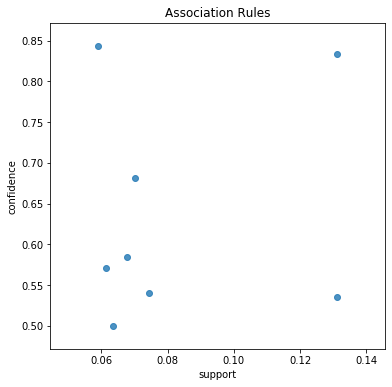

```python
plt.figure(figsize=(6, 6))
plt.title('Association Rules')
plt.xlabel('support')
plt.ylabel('confidence')
sns.regplot(x=support, y=confidence, fit_reg=False)
```

1. Import module fpgrowth từ thư viện mlxtend và tìm tập phổ biến bằng thuật toán FP-Growth

```python
from mlxtend.frequent_patterns import fpgrowth
itemsets = fpgrowth(basket, min_support=0.03, use_colnames=True)
```

Xem 10 phần tử đầu tiên trong tập phổ biến tìm được

```python
itemsets.head(10)
```

|  | support | itemsets |
| --- | --- | --- |
| 0 | 0.100656 | (JUMBO BAG WOODLAND ANIMALS) |
| 1 | 0.037199 | (5 HOOK HANGER RED MAGIC TOADSTOOL) |
| 2 | 0.032823 | (3 HOOK HANGER MAGIC GARDEN) |
| 3 | 0.030635 | (CHILDREN'S CIRCUS PARADE MUG) |
| 4 | 0.102845 | (6 RIBBONS RUSTIC CHARM) |
| 5 | 0.091904 | (JAM MAKING SET PRINTED) |
| 6 | 0.085339 | (PACK OF 72 RETROSPOT CAKE CASES) |
| 7 | 0.063457 | (JAM JAR WITH PINK LID) |
| 8 | 0.035011 | (JAM JAR WITH GREEN LID) |
| 9 | 0.043764 | (CHILDS BREAKFAST SET CIRCUS PARADE) |

1. Tạo luật kết hợp với min_conf = 50%

```python
rules = association_rules(itemsets, metric='confidence', min_threshold=0.5)
```

Xem thông tin về tập luật

```python
rules.info()
```

```
<class 'pandas.core.frame.DataFrame'>
RangeIndex: 71 entries, 0 to 70
Data columns (total 9 columns):
 #   Column              Non-Null Count  Dtype
---  ------              --------------  -----
 0   antecedents         71 non-null     object
 1   consequents         71 non-null     object
 2   antecedent support  71 non-null     float64
 3   consequent support  71 non-null     float64
 4   support             71 non-null     float64
 5   confidence          71 non-null     float64
 6   lift                71 non-null     float64
 7   leverage            71 non-null     float64
 8   conviction          71 non-null     float64
dtypes: float64(7), object(2)
memory usage: 5.1+ KB
```

Chuyển đổi vế trái và vế phải từ kiểu object (frozenset) về kiểu chuỗi (unicode)

```python
rules["antecedents"] = rules["antecedents"].apply(lambda x: list(x)[0]).astype("unicode")
rules["consequents"] = rules["consequents"].apply(lambda x: list(x)[0]).astype("unicode")
```

Viết lệnh in ra các luật đã tìm được

```python
for i in range(len(rules)):
    print(rules.loc[i, 'antecedents'],' ==> ', rules.loc[i, 'consequents'],
         ' [', rules.loc[i, 'support'], ', ', rules.loc[i, 'confidence'], ']')
```

```
JAM JAR WITH PINK LID  ==>  JAM JAR WITH GREEN LID  [ 0.03282275711159737 ,  0.5172413793103448 ]
JAM JAR WITH GREEN LID  ==>  JAM JAR WITH PINK LID  [ 0.03282275711159737 ,  0.9375 ]
JUMBO BAG RED RETROSPOT  ==>  JUMBO BAG WOODLAND ANIMALS  [ 0.04814004376367615 ,  0.611111111111111 ]
WOODLAND PARTY BAG + STICKER SET  ==>  ROUND SNACK BOXES SET OF4 WOODLAND  [ 0.037199124726477024 ,  0.5483870967741935 ]
ROUND SNACK BOXES SET OF 4 FRUITS  ==>  ROUND SNACK BOXES SET OF4 WOODLAND  [ 0.13129102844638948 ,  0.8333333333333333 ]
ROUND SNACK BOXES SET OF4 WOODLAND  ==>  ROUND SNACK BOXES SET OF 4 FRUITS  [ 0.13129102844638948 ,  0.5357142857142857 ]
WOODLAND CHARLOTTE BAG  ==>  ROUND SNACK BOXES SET OF4 WOODLAND  [ 0.06345733041575492 ,  0.5 ]
ROUND SNACK BOXES SET OF 4 FRUITS  ==>  ROUND SNACK BOXES SET OF4 WOODLAND  [ 0.03938730853391685 ,  0.8571428571428572 ]
ROUND SNACK BOXES SET OF4 WOODLAND  ==>  ROUND SNACK BOXES SET OF 4 FRUITS  [ 0.03938730853391685 ,  0.6206896551724138 ]
PLASTERS IN TIN CIRCUS PARADE  ==>  PLASTERS IN TIN WOODLAND ANIMALS  [ 0.06783369803063458 ,  0.5849056603773585 ]
PLASTERS IN TIN CIRCUS PARADE  ==>  ROUND SNACK BOXES SET OF4 WOODLAND  [ 0.03938730853391685 ,  0.5806451612903226 ]
PLASTERS IN TIN CIRCUS PARADE  ==>  PLASTERS IN TIN WOODLAND ANIMALS  [ 0.03938730853391685 ,  0.6923076923076923 ]
PLASTERS IN TIN WOODLAND ANIMALS  ==>  PLASTERS IN TIN CIRCUS PARADE  [ 0.03938730853391685 ,  0.5294117647058824 ]
ROUND SNACK BOXES SET OF 4 FRUITS  ==>  ROUND SNACK BOXES SET OF4 WOODLAND  [ 0.04157549234135667 ,  0.826086956521739 ]
PLASTERS IN TIN CIRCUS PARADE  ==>  ROUND SNACK BOXES SET OF 4 FRUITS  [ 0.04157549234135667 ,  0.7307692307692307 ]
SPACEBOY LUNCH BOX  ==>  ROUND SNACK BOXES SET OF4 WOODLAND  [ 0.0700218818380744 ,  0.6808510638297872 ]
SPACEBOY LUNCH BOX  ==>  ROUND SNACK BOXES SET OF4 WOODLAND  [ 0.037199124726477024 ,  0.9444444444444444 ]
SPACEBOY LUNCH BOX  ==>  ROUND SNACK BOXES SET OF 4 FRUITS  [ 0.037199124726477024 ,  0.53125 ]
RED RETROSPOT CHARLOTTE BAG  ==>  WOODLAND CHARLOTTE BAG  [ 0.05908096280087528 ,  0.8437500000000001 ]
ROUND SNACK BOXES SET OF4 WOODLAND  ==>  WOODLAND CHARLOTTE BAG  [ 0.030634573304157548 ,  1.0 ]
RED RETROSPOT CHARLOTTE BAG  ==>  ROUND SNACK BOXES SET OF4 WOODLAND  [ 0.030634573304157548 ,  0.5185185185185185 ]
RED RETROSPOT MINI CASES  ==>  ROUND SNACK BOXES SET OF4 WOODLAND  [ 0.037199124726477024 ,  0.5666666666666668 ]
RETROSPOT PARTY BAG + STICKER SET  ==>  WOODLAND PARTY BAG + STICKER SET  [ 0.030634573304157548 ,  0.5 ]
SET OF 2 TEA TOWELS APPLE AND PEARS  ==>  ROUND SNACK BOXES SET OF4 WOODLAND  [ 0.030634573304157548 ,  0.6363636363636364 ]
BLUE HARMONICA IN BOX  ==>  ROUND SNACK BOXES SET OF4 WOODLAND  [ 0.03282275711159737 ,  0.6818181818181818 ]
PLASTERS IN TIN WOODLAND ANIMALS  ==>  ROUND SNACK BOXES SET OF4 WOODLAND  [ 0.07439824945295405 ,  0.5396825396825397 ]
ROUND SNACK BOXES SET OF 4 FRUITS  ==>  ROUND SNACK BOXES SET OF4 WOODLAND  [ 0.04157549234135667 ,  0.8636363636363635 ]
PLASTERS IN TIN WOODLAND ANIMALS  ==>  ROUND SNACK BOXES SET OF 4 FRUITS  [ 0.04157549234135667 ,  0.5588235294117646 ]
RED RETROSPOT CUP  ==>  ROUND SNACK BOXES SET OF4 WOODLAND  [ 0.037199124726477024 ,  0.53125 ]
PINK  POLKADOT CUP  ==>  RED RETROSPOT CUP  [ 0.030634573304157548 ,  0.7777777777777777 ]
JUMBO BAG PINK POLKADOT  ==>  JUMBO BAG RED RETROSPOT  [ 0.03282275711159737 ,  0.9375 ]
RED RETROSPOT CUP  ==>  BLUE POLKADOT CUP  [ 0.0350109409190372 ,  0.5 ]
BLUE POLKADOT CUP  ==>  RED RETROSPOT CUP  [ 0.0350109409190372 ,  0.7272727272727272 ]
RED RETROSPOT PLATE  ==>  RED RETROSPOT CUP  [ 0.030634573304157548 ,  0.6666666666666666 ]
PLASTERS IN TIN SPACEBOY  ==>  PLASTERS IN TIN WOODLAND ANIMALS  [ 0.061269146608315096 ,  0.5714285714285714 ]
PLASTERS IN TIN SPACEBOY  ==>  ROUND SNACK BOXES SET OF4 WOODLAND  [ 0.0350109409190372 ,  0.5714285714285714 ]
PLASTERS IN TIN SPACEBOY  ==>  PLASTERS IN TIN WOODLAND ANIMALS  [ 0.0350109409190372 ,  0.7272727272727272 ]
PLASTERS IN TIN SPACEBOY  ==>  PLASTERS IN TIN WOODLAND ANIMALS  [ 0.0350109409190372 ,  0.7272727272727272 ]
PLASTERS IN TIN SPACEBOY  ==>  PLASTERS IN TIN CIRCUS PARADE  [ 0.0350109409190372 ,  0.5714285714285714 ]
PLASTERS IN TIN CIRCUS PARADE  ==>  PLASTERS IN TIN SPACEBOY  [ 0.0350109409190372 ,  0.5161290322580645 ]
```

[output cut: 16 more lines]

```
LUNCH BAG RED RETROSPOT  ==>  LUNCH BAG WOODLAND  [ 0.03282275711159737 ,  0.75 ]
COFFEE MUG APPLES DESIGN  ==>  ROUND SNACK BOXES SET OF4 WOODLAND  [ 0.03282275711159737 ,  0.5357142857142857 ]
COFFEE MUG APPLES DESIGN  ==>  COFFEE MUG PEARS  DESIGN  [ 0.0350109409190372 ,  0.5714285714285714 ]
COFFEE MUG PEARS  DESIGN  ==>  COFFEE MUG APPLES DESIGN  [ 0.0350109409190372 ,  0.8888888888888888 ]
JUMBO BAG APPLES  ==>  CHARLOTTE BAG APPLES DESIGN  [ 0.030634573304157548 ,  0.5 ]
CHARLOTTE BAG APPLES DESIGN  ==>  ROUND SNACK BOXES SET OF4 WOODLAND  [ 0.03938730853391685 ,  0.6000000000000001 ]
CHARLOTTE BAG APPLES DESIGN  ==>  WOODLAND CHARLOTTE BAG  [ 0.03282275711159737 ,  0.5 ]
CHARLOTTE BAG APPLES DESIGN  ==>  ROUND SNACK BOXES SET OF 4 FRUITS  [ 0.03282275711159737 ,  0.5 ]
ROUND SNACK BOXES SET OF 4 FRUITS  ==>  ROUND SNACK BOXES SET OF4 WOODLAND  [ 0.030634573304157548 ,  0.9333333333333333 ]
CHARLOTTE BAG APPLES DESIGN  ==>  ROUND SNACK BOXES SET OF 4 FRUITS  [ 0.030634573304157548 ,  0.7777777777777777 ]
LUNCH BAG APPLE DESIGN  ==>  ROUND SNACK BOXES SET OF4 WOODLAND  [ 0.0350109409190372 ,  0.5714285714285714 ]
CHILDRENS CUTLERY SPACEBOY  ==>  CHILDRENS CUTLERY DOLLY GIRL  [ 0.03938730853391685 ,  0.8181818181818182 ]
CHILDRENS CUTLERY DOLLY GIRL  ==>  CHILDRENS CUTLERY SPACEBOY  [ 0.03938730853391685 ,  0.782608695652174 ]
SPACEBOY CHILDRENS BOWL  ==>  SPACEBOY CHILDRENS CUP  [ 0.037199124726477024 ,  0.8947368421052633 ]
SPACEBOY CHILDRENS CUP  ==>  SPACEBOY CHILDRENS BOWL  [ 0.037199124726477024 ,  0.8500000000000001 ]
```

1. Lấy gía trị độ hỗ trợ và độ tin cậy của tập luật

```python
support=rules['support'].values
confidence=rules['confidence'].values
```

Biểu diễn thông tin này lên biểu đồ

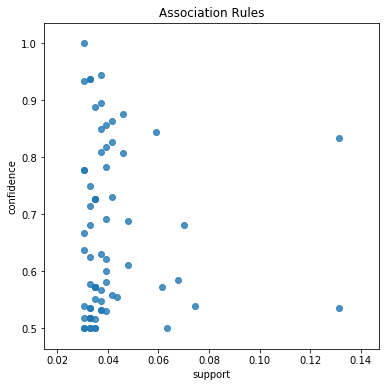

```python
plt.figure(figsize=(6, 6))
plt.title('Association Rules')
plt.xlabel('support')
plt.ylabel('confidence')
sns.regplot(x=support, y=confidence, fit_reg=False)
```

Kết quả thu được hình trên